# Submission 2 - Holt Winter

2024-07-30

| Nama : Ahmad Syahid Ibnu Syarif |
| --- |
| Satker : BPS Kota Dumai Provinsi Riau |

Pada Script ini terdapat beberapa package yang digunakan. Dapat diinstall sebelum menjalankan script

```r
##install.packages(c('ggplot2','tseries','forecast','DMwR',"here"))
```

set directory (bila perlu)

```r
library(here)
getwd()
```

```
## [1] "D:/LEARNING/INDAthon"
```

```r
## setwd(here('dataset'))
## dapat disesuaikan, setwd() dengan here bisa digunakan jika diluar chunk
```

### Load Library

```r
library(ggplot2)
library(tseries)
library(forecast)
```

### Load Data dan melihat struktur data

```r
pnmpg_tj<-read.csv("dataset/training_jumlah_penumpang_tj.csv",sep=";")
head(pnmpg_tj)
```

```
##   bulan tahun jumlah_penumpang
## 1     1  2015          8738599
## 2     2  2015          7630313
## 3     3  2015          9383835
## 4     4  2015          8832441
## 5     5  2015          9035420
## 6     6  2015          8692562
```

```r
str(pnmpg_tj)
```

```
## 'data.frame':    108 obs. of  3 variables:
##  $ bulan           : int  1 2 3 4 5 6 7 8 9 10 ...
##  $ tahun           : int  2015 2015 2015 2015 2015 2015 2015 2015 2015 2015 ...
##  $ jumlah_penumpang: int  8738599 7630313 9383835 8832441 9035420 8692562 7615995 8802642 8455633 8730480 ...
```

Load data Auxilary dan meliaht struktur data auxilary

```r
armd_tj<-read.csv("dataset/jumlah_armada_tj.csv",sep=";")
pnmpg_lrt<-read.csv("dataset/jumlah_penumpang_lrt.csv",sep=";")
pnmpg_mrt<-read.csv("dataset/jumlah_penumpang_mrt.csv",sep=";")
prjln_lrt<-read.csv("dataset/jumlah_perjalanan_lrt.csv",sep=";")
prjln_mrt<-read.csv("dataset/jumlah_perjalanan_mrt.csv",sep=";")

head(armd_tj)
```

```
##   bulan tahun jumlah_armada_tj
## 1     1  2023             3853
## 2     2  2023             3864
## 3     3  2023             3890
## 4     4  2023             3853
## 5     5  2023             3944
## 6     6  2023             3980
```

```r
head(pnmpg_lrt)
```

```
##   bulan tahun jumlah_penumpang
## 1     1  2023            72424
## 2     2  2023            76166
## 3     3  2023            82754
## 4     4  2023            72318
## 5     5  2023            78639
## 6     6  2023            84008
```

```r
head(pnmpg_mrt)
```

```
##   bulan tahun jumlah_penumpang
## 1     1  2023          2540315
## 2     2  2023          2378568
## 3     3  2023          2699585
## 4     4  2023          2065546
## 5     5  2023          2681876
## 6     6  2023          2709731
```

```r
head(prjln_lrt)
```

```
##   bulan tahun jumlah_perjalanan
## 1     1  2023              6190
## 2     2  2023              5980
## 3     3  2023              6200
## 4     4  2023              5998
## 5     5  2023              6198
## 6     6  2023              6098
```

```r
head(prjln_mrt)
```

```
##   bulan tahun jumlah_perjalanan
## 1     1  2023              8035
## 2     2  2023              7340
## 3     3  2023              8035
## 4     4  2023              7270
## 5     5  2023              8161
## 6     6  2023              7688
```

### Combine all data auxilary

Lima data auxilary yang tersedia memiliki dimensi yang sama. Untuk mempermudah melihat data auxilary, data tersebut digabung menjadi satu dataframe.

```r
data_aux<-armd_tj
data_aux['pnmpg_lrt']<-pnmpg_lrt['jumlah_penumpang']
data_aux['pnmpg_mrt']<-pnmpg_mrt['jumlah_penumpang']
data_aux['prjln_lrt']<-prjln_lrt['jumlah_perjalanan']
data_aux['prjln_mrt']<-prjln_mrt['jumlah_perjalanan']
head(data_aux)
```

```
##   bulan tahun jumlah_armada_tj pnmpg_lrt pnmpg_mrt prjln_lrt prjln_mrt
## 1     1  2023             3853     72424   2540315      6190      8035
## 2     2  2023             3864     76166   2378568      5980      7340
## 3     3  2023             3890     82754   2699585      6200      8035
## 4     4  2023             3853     72318   2065546      5998      7270
## 5     5  2023             3944     78639   2681876      6198      8161
## 6     6  2023             3980     84008   2709731      6098      7688
```

### Persiapan Pemodelan

Untuk analisi time series, perlu ada variabel penujuk waktu, yaitu variabel dengan format ‘date’.

```r
pnmpg_tj$date<-paste(pnmpg_tj$tahun,pnmpg_tj$bulan,"01",sep="-")
pnmpg_tj$date<-as.Date(as.character(pnmpg_tj$date),format="%Y-%m-%d")
str(pnmpg_tj)
```

```
## 'data.frame':    108 obs. of  4 variables:
##  $ bulan           : int  1 2 3 4 5 6 7 8 9 10 ...
##  $ tahun           : int  2015 2015 2015 2015 2015 2015 2015 2015 2015 2015 ...
##  $ jumlah_penumpang: int  8738599 7630313 9383835 8832441 9035420 8692562 7615995 8802642 8455633 8730480 ...
##  $ date            : Date, format: "2015-01-01" "2015-02-01" ...
```

### Menampilkan Grafik

Menampilkan plot line chart dari data jumlah penumpang Transjakarta

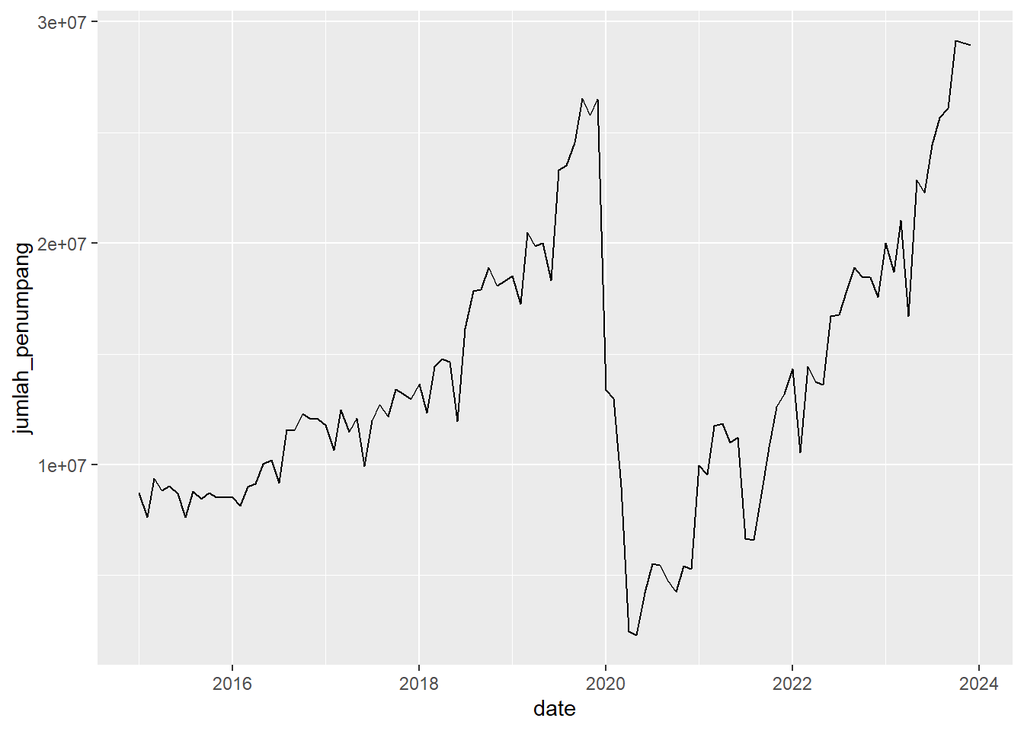

```r
ggplot(pnmpg_tj, aes(x=date, y=jumlah_penumpang)) +
  geom_line()
```

Secara visual terlihat bahwa jumlah penumpang Transjakarta mengalami penurunan drastispada masa Pandemi Covid-19 tahun 2020 hingga 2022. Secara visual juga terlihat bahwa data jumlah penumpang transjakarta tidak stasioner.

### uji coba Pemodelan Holt Winters

Sebelum uji coba Holt Winters, data harus dikonversi ke dalam format time series dengan function ts()

```r
tj_ts<-pnmpg_tj[,c("jumlah_penumpang","bulan","tahun")]
head(tj_ts)
```

```
##   jumlah_penumpang bulan tahun
## 1          8738599     1  2015
## 2          7630313     2  2015
## 3          9383835     3  2015
## 4          8832441     4  2015
## 5          9035420     5  2015
## 6          8692562     6  2015
```

```r
TJ.ts <- ts(tj_ts, frequency = 12, start = c(2015,1), end = c(2023,12))
class(TJ.ts)
```

```
## [1] "mts"    "ts"     "matrix" "array"
```

```r
head(TJ.ts)
```

```
##          jumlah_penumpang bulan tahun
## Jan 2015          8738599     1  2015
## Feb 2015          7630313     2  2015
## Mar 2015          9383835     3  2015
## Apr 2015          8832441     4  2015
## May 2015          9035420     5  2015
## Jun 2015          8692562     6  2015
```

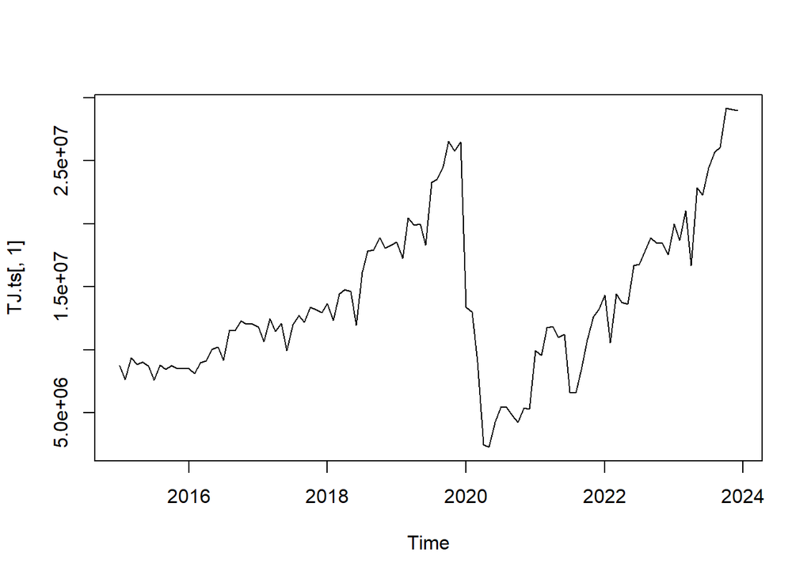

```r
plot.ts(TJ.ts[,1])
```

### Transformasi Data

Dari Grafik terlihat bahwa data tidak stasioner. Oleh karena itu, data harus ditransformasi terlebih dahulu. Setelah ditransformasi, perlu dilihat grafik dekomposisinya.

```r
log_pnmpg_tj<-log(TJ.ts[,1])
log_pnmpg_tj
```

```
##           Jan      Feb      Mar      Apr      May      Jun      Jul      Aug
## 2015 15.98326 15.84764 16.05450 15.99394 16.01666 15.97798 15.84576 15.99056
## 2016 15.95687 15.91303 16.01367 16.02729 16.12029 16.13874 16.03085 16.26482
## 2017 16.28332 16.18019 16.33996 16.25726 16.30975 16.11033 16.29947 16.35696
## 2018 16.42954 16.32791 16.48530 16.50934 16.49848 16.29646 16.59809 16.69724
## 2019 16.73473 16.66313 16.83519 16.80522 16.81111 16.72296 16.96402 16.97368
## 2020 16.40905 16.38000 16.01440 14.72417 14.64056 15.25724 15.52298 15.50966
## 2021 16.11449 16.07058 16.28004 16.28733 16.21177 16.23446 15.70983 15.70030
## 2022 16.47738 16.17164 16.48482 16.43699 16.42734 16.63026 16.63534 16.69863
## 2023 16.81131 16.74458 16.86225 16.63014 16.94425 16.91852 17.01125 17.06175
##           Sep      Oct      Nov      Dec
## 2015 15.95034 15.98233 15.95758 15.95750
## 2016 16.26063 16.32560 16.30448 16.30435
## 2017 16.31470 16.41047 16.39616 16.37732
## 2018 16.70136 16.75402 16.71063 16.72194
## 2019 17.01629 17.09415 17.06536 17.09271
## 2020 15.38037 15.26595 15.50450 15.48359
## 2021 15.97365 16.19515 16.34945 16.39588
## 2022 16.75467 16.73198 16.73160 16.68102
## 2023 17.07653 17.18785 17.18496 17.18134
```

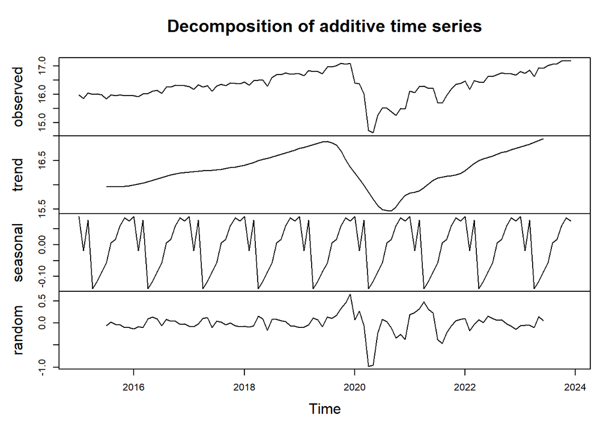

```r
D<-decompose(log_pnmpg_tj)
plot(D)
```

### Forecasting

Forecasting (peramalan) menggunakan metode Holt Winters

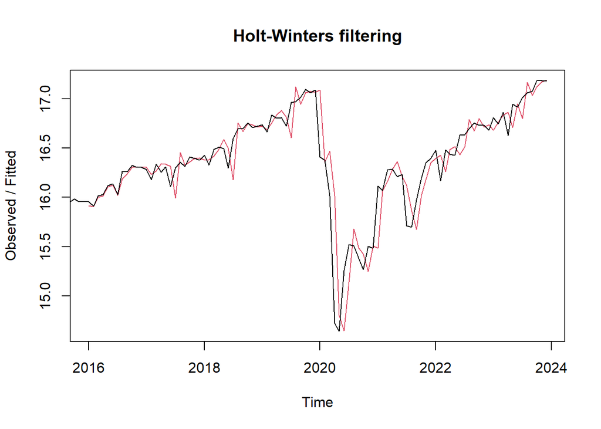

```r
forecast1<-HoltWinters(log_pnmpg_tj)
plot(forecast1)
```

```r
forecast2 = forecast:::forecast.HoltWinters(forecast1, h=6)
forecast2$mean
```

```
##           Jan      Feb      Mar      Apr      May      Jun
## 2024 17.18096 17.13265 17.22360 17.22466 17.30357 17.30777
```

Traning model pada bentuk transformasi(log), sehingga hasil peramalan juga dalam bentuk log. Untuk itu perlu ditransformasi kembali untuk mendapatkan hasil peramalan yang riil.

```r
ramalan<-exp(forecast2$mean)
ramalan
```

```
##           Jan      Feb      Mar      Apr      May      Jun
## 2024 28946642 27581403 30207566 30239548 32722360 32860184
```

### Export hasil peramalan

Hasil peramalan harus diubah kedalam bentuk .csv sesuai format yang dibutuhkan

```r
hasil2<- data.frame("id"=c(1:6),"jumlah_penumpang"=round(ramalan))
hasil2
```

```
##   id jumlah_penumpang
## 1  1         28946642
## 2  2         27581403
## 3  3         30207566
## 4  4         30239548
## 5  5         32722360
## 6  6         32860184
```

```r
str(hasil2)
```

```
## 'data.frame':    6 obs. of  2 variables:
##  $ id              : int  1 2 3 4 5 6
##  $ jumlah_penumpang: Time-Series  from 2024 to 2024: 28946642 27581403 30207566 30239548 32722360 ...
```

### Export ke CSV

```r
write.csv(hasil2,"./submission4.csv", row.names = FALSE)
## hasil yang tertera pada markdown ini adalah hasil percobaan keempat
```